# Part I - (Prosper Loan Data Exploration)

```python
#This checks the dimension of the dataframe
df.shape
```

```
(55267, 81)
```

```python
#Gives the datatype of all columns
df.dtypes
```

```
ListingKey                              object
ListingNumber                            int64
ListingCreationDate                     object
CreditGrade                             object
Term                                     int64
LoanStatus                              object
ClosedDate                              object
BorrowerAPR                            float64
BorrowerRate                           float64
LenderYield                            float64
EstimatedEffectiveYield                float64
EstimatedLoss                          float64
EstimatedReturn                        float64
ProsperRating (numeric)                float64
ProsperRating (Alpha)                   object
ProsperScore                           float64
ListingCategory (numeric)              float64
BorrowerState                           object
Occupation                              object
EmploymentStatus                        object
EmploymentStatusDuration               float64
IsBorrowerHomeowner                     object
CurrentlyInGroup                        object
GroupKey                                object
DateCreditPulled                        object
CreditScoreRangeLower                  float64
CreditScoreRangeUpper                  float64
FirstRecordedCreditLine                 object
CurrentCreditLines                     float64
OpenCreditLines                        float64
                                        ...
TotalProsperLoans                      float64
TotalProsperPaymentsBilled             float64
OnTimeProsperPayments                  float64
ProsperPaymentsLessThanOneMonthLate    float64
ProsperPaymentsOneMonthPlusLate        float64
ProsperPrincipalBorrowed               float64
ProsperPrincipalOutstanding            float64
ScorexChangeAtTimeOfListing            float64
LoanCurrentDaysDelinquent              float64
LoanFirstDefaultedCycleNumber          float64
LoanMonthsSinceOrigination             float64
LoanNumber                             float64
LoanOriginalAmount                     float64
LoanOriginationDate                     object
LoanOriginationQuarter                  object
MemberKey                               object
MonthlyLoanPayment                     float64
LP_CustomerPayments                    float64
LP_CustomerPrincipalPayments           float64
LP_InterestandFees                     float64
LP_ServiceFees                         float64
LP_CollectionFees                      float64
LP_GrossPrincipalLoss                  float64
LP_NetPrincipalLoss                    float64
LP_NonPrincipalRecoverypayments        float64
PercentFunded                          float64
Recommendations                        float64
InvestmentFromFriendsCount             float64
InvestmentFromFriendsAmount            float64
Investors                              float64
Length: 81, dtype: object
```

```python
#Listing Columns names in a list
df.columns
```

```
Index(['ListingKey', 'ListingNumber', 'ListingCreationDate', 'CreditGrade',
       'Term', 'LoanStatus', 'ClosedDate', 'BorrowerAPR', 'BorrowerRate',
       'LenderYield', 'EstimatedEffectiveYield', 'EstimatedLoss',
       'EstimatedReturn', 'ProsperRating (numeric)', 'ProsperRating (Alpha)',
       'ProsperScore', 'ListingCategory (numeric)', 'BorrowerState',
       'Occupation', 'EmploymentStatus', 'EmploymentStatusDuration',
       'IsBorrowerHomeowner', 'CurrentlyInGroup', 'GroupKey',
       'DateCreditPulled', 'CreditScoreRangeLower', 'CreditScoreRangeUpper',
       'FirstRecordedCreditLine', 'CurrentCreditLines', 'OpenCreditLines',
       'TotalCreditLinespast7years', 'OpenRevolvingAccounts',
       'OpenRevolvingMonthlyPayment', 'InquiriesLast6Months', 'TotalInquiries',
       'CurrentDelinquencies', 'AmountDelinquent', 'DelinquenciesLast7Years',
       'PublicRecordsLast10Years', 'PublicRecordsLast12Months',
       'RevolvingCreditBalance', 'BankcardUtilization',
       'AvailableBankcardCredit', 'TotalTrades',
       'TradesNeverDelinquent (percentage)', 'TradesOpenedLast6Months',
       'DebtToIncomeRatio', 'IncomeRange', 'IncomeVerifiable',
       'StatedMonthlyIncome', 'LoanKey', 'TotalProsperLoans',
       'TotalProsperPaymentsBilled', 'OnTimeProsperPayments',
       'ProsperPaymentsLessThanOneMonthLate',
       'ProsperPaymentsOneMonthPlusLate', 'ProsperPrincipalBorrowed',
       'ProsperPrincipalOutstanding', 'ScorexChangeAtTimeOfListing',
       'LoanCurrentDaysDelinquent', 'LoanFirstDefaultedCycleNumber',
       'LoanMonthsSinceOrigination', 'LoanNumber', 'LoanOriginalAmount',
       'LoanOriginationDate', 'LoanOriginationQuarter', 'MemberKey',
       'MonthlyLoanPayment', 'LP_CustomerPayments',
       'LP_CustomerPrincipalPayments', 'LP_InterestandFees', 'LP_ServiceFees',
       'LP_CollectionFees', 'LP_GrossPrincipalLoss', 'LP_NetPrincipalLoss',
       'LP_NonPrincipalRecoverypayments', 'PercentFunded', 'Recommendations',
       'InvestmentFromFriendsCount', 'InvestmentFromFriendsAmount',
       'Investors'],
      dtype='object')
```

```python
#Change some of the datatype of the columns into it correct datatype
df[['ListingCreationDate', 'ClosedDate', 'DateCreditPulled', 'LoanOriginationDate', 'FirstRecordedCreditLine']] = df[['ListingCreationDate', 'ClosedDate', 'DateCreditPulled', 'LoanOriginationDate', 'FirstRecordedCreditLine']].astype('datetime64[ns]')
```

```python
df.info()
```

```
<class 'pandas.core.frame.DataFrame'>
RangeIndex: 55267 entries, 0 to 55266
Data columns (total 81 columns):
ListingKey                             55267 non-null object
ListingNumber                          55267 non-null int64
ListingCreationDate                    55267 non-null datetime64[ns]
CreditGrade                            14053 non-null object
Term                                   55267 non-null int64
LoanStatus                             55267 non-null object
ClosedDate                             26756 non-null datetime64[ns]
BorrowerAPR                            55259 non-null float64
BorrowerRate                           55266 non-null float64
LenderYield                            55266 non-null float64
EstimatedEffectiveYield                41155 non-null float64
EstimatedLoss                          41155 non-null float64
EstimatedReturn                        41155 non-null float64
ProsperRating (numeric)                41155 non-null float64
ProsperRating (Alpha)                  41155 non-null object
ProsperScore                           41155 non-null float64
ListingCategory (numeric)              55266 non-null float64
BorrowerState                          52629 non-null object
Occupation                             53557 non-null object
EmploymentStatus                       54198 non-null object
EmploymentStatusDuration               51580 non-null float64
IsBorrowerHomeowner                    55266 non-null object
CurrentlyInGroup                       55266 non-null object
GroupKey                               6475 non-null object
DateCreditPulled                       55266 non-null datetime64[ns]
CreditScoreRangeLower                  54977 non-null float64
CreditScoreRangeUpper                  54977 non-null float64
FirstRecordedCreditLine                54928 non-null datetime64[ns]
CurrentCreditLines                     51593 non-null float64
OpenCreditLines                        51593 non-null float64
TotalCreditLinespast7years             54928 non-null float64
OpenRevolvingAccounts                  55266 non-null float64
OpenRevolvingMonthlyPayment            55266 non-null float64
InquiriesLast6Months                   54928 non-null float64
TotalInquiries                         54710 non-null float64
CurrentDelinquencies                   54928 non-null float64
AmountDelinquent                       51584 non-null float64
```

[output cut: 31 more lines]

```
LP_CustomerPayments                    55266 non-null float64
LP_CustomerPrincipalPayments           55266 non-null float64
LP_InterestandFees                     55266 non-null float64
LP_ServiceFees                         55266 non-null float64
LP_CollectionFees                      55266 non-null float64
LP_GrossPrincipalLoss                  55266 non-null float64
LP_NetPrincipalLoss                    55266 non-null float64
LP_NonPrincipalRecoverypayments        55266 non-null float64
PercentFunded                          55266 non-null float64
Recommendations                        55266 non-null float64
InvestmentFromFriendsCount             55266 non-null float64
InvestmentFromFriendsAmount            55266 non-null float64
Investors                              55266 non-null float64
dtypes: datetime64[ns](5), float64(59), int64(2), object(15)
memory usage: 34.2+ MB
```

```python
#Print the first 7 rows
df.head(7)
```

|  | ListingKey | ListingNumber | ListingCreationDate | CreditGrade | Term | LoanStatus | ClosedDate | BorrowerAPR | BorrowerRate | LenderYield | ... | LP_ServiceFees | LP_CollectionFees | LP_GrossPrincipalLoss | LP_NetPrincipalLoss | LP_NonPrincipalRecoverypayments | PercentFunded | Recommendations | InvestmentFromFriendsCount | InvestmentFromFriendsAmount | Investors |
| --- | --- | --- | --- | --- | --- | --- | --- | --- | --- | --- | --- | --- | --- | --- | --- | --- | --- | --- | --- | --- | --- |
| 0 | 1021339766868145413AB3B | 193129 | 2007-08-26 19:09:29.263 | C | 36 | Completed | 2009-08-14 | 0.16516 | 0.1580 | 0.1380 | ... | -133.18 | 0.0 | 0.0 | 0.0 | 0.0 | 1.0 | 0.0 | 0.0 | 0.0 | 258.0 |
| 1 | 10273602499503308B223C1 | 1209647 | 2014-02-27 08:28:07.900 | NaN | 36 | Current | NaT | 0.12016 | 0.0920 | 0.0820 | ... | 0.00 | 0.0 | 0.0 | 0.0 | 0.0 | 1.0 | 0.0 | 0.0 | 0.0 | 1.0 |
| 2 | 0EE9337825851032864889A | 81716 | 2007-01-05 15:00:47.090 | HR | 36 | Completed | 2009-12-17 | 0.28269 | 0.2750 | 0.2400 | ... | -24.20 | 0.0 | 0.0 | 0.0 | 0.0 | 1.0 | 0.0 | 0.0 | 0.0 | 41.0 |
| 3 | 0EF5356002482715299901A | 658116 | 2012-10-22 11:02:35.010 | NaN | 36 | Current | NaT | 0.12528 | 0.0974 | 0.0874 | ... | -108.01 | 0.0 | 0.0 | 0.0 | 0.0 | 1.0 | 0.0 | 0.0 | 0.0 | 158.0 |
| 4 | 0F023589499656230C5E3E2 | 909464 | 2013-09-14 18:38:39.097 | NaN | 36 | Current | NaT | 0.24614 | 0.2085 | 0.1985 | ... | -60.27 | 0.0 | 0.0 | 0.0 | 0.0 | 1.0 | 0.0 | 0.0 | 0.0 | 20.0 |
| 5 | 0F05359734824199381F61D | 1074836 | 2013-12-14 08:26:37.093 | NaN | 60 | Current | NaT | 0.15425 | 0.1314 | 0.1214 | ... | -25.33 | 0.0 | 0.0 | 0.0 | 0.0 | 1.0 | 0.0 | 0.0 | 0.0 | 1.0 |
| 6 | 0F0A3576754255009D63151 | 750899 | 2013-04-12 09:52:56.147 | NaN | 36 | Current | NaT | 0.31032 | 0.2712 | 0.2612 | ... | -22.95 | 0.0 | 0.0 | 0.0 | 0.0 | 1.0 | 0.0 | 0.0 | 0.0 | 1.0 |

7 rows × 81 columns

```python
#Checking the number of null values in each column
null_value =df.isnull().sum()
null_value
```

```
ListingKey                                 0
ListingNumber                              0
ListingCreationDate                        0
CreditGrade                            41214
Term                                       0
LoanStatus                                 0
ClosedDate                             28511
BorrowerAPR                                8
BorrowerRate                               1
LenderYield                                1
EstimatedEffectiveYield                14112
EstimatedLoss                          14112
EstimatedReturn                        14112
ProsperRating (numeric)                14112
ProsperRating (Alpha)                  14112
ProsperScore                           14112
ListingCategory (numeric)                  1
BorrowerState                           2638
Occupation                              1710
EmploymentStatus                        1069
EmploymentStatusDuration                3687
IsBorrowerHomeowner                        1
CurrentlyInGroup                           1
GroupKey                               48792
DateCreditPulled                           1
CreditScoreRangeLower                    290
CreditScoreRangeUpper                    290
FirstRecordedCreditLine                  339
CurrentCreditLines                      3674
OpenCreditLines                         3674
                                       ...
TotalProsperLoans                      44607
TotalProsperPaymentsBilled             44607
OnTimeProsperPayments                  44607
ProsperPaymentsLessThanOneMonthLate    44607
ProsperPaymentsOneMonthPlusLate        44607
ProsperPrincipalBorrowed               44607
ProsperPrincipalOutstanding            44607
ScorexChangeAtTimeOfListing            46170
LoanCurrentDaysDelinquent                  1
LoanFirstDefaultedCycleNumber          47084
LoanMonthsSinceOrigination                 1
LoanNumber                                 1
LoanOriginalAmount                         1
LoanOriginationDate                        1
LoanOriginationQuarter                     1
MemberKey                                  1
MonthlyLoanPayment                         1
LP_CustomerPayments                        1
LP_CustomerPrincipalPayments               1
LP_InterestandFees                         1
LP_ServiceFees                             1
LP_CollectionFees                          1
LP_GrossPrincipalLoss                      1
LP_NetPrincipalLoss                        1
LP_NonPrincipalRecoverypayments            1
PercentFunded                              1
Recommendations                            1
InvestmentFromFriendsCount                 1
InvestmentFromFriendsAmount                1
Investors                                  1
Length: 81, dtype: int64
```

```python
#Dropping all null value
#df.dropna(inplace=True)
```

```python
df['IncomeRange'].value_counts()
```

```
$25,000-49,999    15628
$50,000-74,999    15146
$100,000+          8453
$75,000-99,999     8097
Not displayed      3744
$1-24,999          3541
Not employed        360
$0                  297
Name: IncomeRange, dtype: int64
```

```python
#Verifying if the null values has been dropped
#df.isnull().sum()
```

```python
#Check the number of duplicates
sum(df.duplicated())
```

```
0
```

```python
#Give a summary of your data
df.describe()
```

|  | ListingNumber | Term | BorrowerAPR | BorrowerRate | LenderYield | EstimatedEffectiveYield | EstimatedLoss | EstimatedReturn | ProsperRating (numeric) | ProsperScore | ... | LP_ServiceFees | LP_CollectionFees | LP_GrossPrincipalLoss | LP_NetPrincipalLoss | LP_NonPrincipalRecoverypayments | PercentFunded | Recommendations | InvestmentFromFriendsCount | InvestmentFromFriendsAmount | Investors |
| --- | --- | --- | --- | --- | --- | --- | --- | --- | --- | --- | --- | --- | --- | --- | --- | --- | --- | --- | --- | --- | --- |
| count | 5.526700e+04 | 55267.000000 | 55259.000000 | 55266.000000 | 55266.000000 | 41155.000000 | 41155.000000 | 41155.000000 | 41155.000000 | 41155.000000 | ... | 55266.000000 | 55266.000000 | 55266.000000 | 55266.000000 | 55266.000000 | 55266.000000 | 55266.000000 | 55266.000000 | 55266.000000 | 55266.000000 |
| mean | 6.283027e+05 | 40.851937 | 0.218563 | 0.192556 | 0.182495 | 0.168441 | 0.080242 | 0.095938 | 4.077293 | 5.962848 | ... | -54.891990 | -14.376396 | 701.128724 | 682.093794 | 25.229559 | 0.998660 | 0.047118 | 0.023106 | 15.643532 | 80.381754 |
| std | 3.279084e+05 | 10.426270 | 0.080427 | 0.074882 | 0.074581 | 0.068664 | 0.046900 | 0.030502 | 1.672782 | 2.376339 | ... | 61.084587 | 114.895958 | 2393.931887 | 2364.760010 | 276.739647 | 0.017356 | 0.341346 | 0.258240 | 272.738609 | 103.122941 |
| min | 6.000000e+00 | 12.000000 | 0.008640 | 0.000000 | -0.010000 | -0.182700 | 0.004900 | -0.182700 | 1.000000 | 1.000000 | ... | -664.870000 | -9274.750000 | -94.200000 | -954.550000 | 0.000000 | 0.700000 | 0.000000 | 0.000000 | 0.000000 | 1.000000 |
| 25% | 4.012810e+05 | 36.000000 | 0.156290 | 0.133400 | 0.123500 | 0.115670 | 0.042400 | 0.074080 | 3.000000 | 4.000000 | ... | -73.085000 | 0.000000 | 0.000000 | 0.000000 | 0.000000 | 1.000000 | 0.000000 | 0.000000 | 0.000000 | 2.000000 |
| 50% | 5.999080e+05 | 36.000000 | 0.209310 | 0.183550 | 0.173000 | 0.161500 | 0.069900 | 0.091400 | 4.000000 | 6.000000 | ... | -34.355000 | 0.000000 | 0.000000 | 0.000000 | 0.000000 | 1.000000 | 0.000000 | 0.000000 | 0.000000 | 44.000000 |
| 75% | 8.933795e+05 | 36.000000 | 0.283700 | 0.250000 | 0.240000 | 0.224300 | 0.112000 | 0.116000 | 5.000000 | 8.000000 | ... | -13.780000 | 0.000000 | 0.000000 | 0.000000 | 0.000000 | 1.000000 | 0.000000 | 0.000000 | 0.000000 | 115.000000 |
| max | 1.255725e+06 | 60.000000 | 0.512290 | 0.497500 | 0.492500 | 0.319900 | 0.366000 | 0.266700 | 7.000000 | 11.000000 | ... | 32.060000 | 0.000000 | 25000.000000 | 25000.000000 | 21117.900000 | 1.004500 | 39.000000 | 33.000000 | 23699.520000 | 1035.000000 |

8 rows × 61 columns

```python
df.info()
```

```
<class 'pandas.core.frame.DataFrame'>
RangeIndex: 55267 entries, 0 to 55266
Data columns (total 81 columns):
ListingKey                             55267 non-null object
ListingNumber                          55267 non-null int64
ListingCreationDate                    55267 non-null datetime64[ns]
CreditGrade                            14053 non-null object
Term                                   55267 non-null int64
LoanStatus                             55267 non-null object
ClosedDate                             26756 non-null datetime64[ns]
BorrowerAPR                            55259 non-null float64
BorrowerRate                           55266 non-null float64
LenderYield                            55266 non-null float64
EstimatedEffectiveYield                41155 non-null float64
EstimatedLoss                          41155 non-null float64
EstimatedReturn                        41155 non-null float64
ProsperRating (numeric)                41155 non-null float64
ProsperRating (Alpha)                  41155 non-null object
ProsperScore                           41155 non-null float64
ListingCategory (numeric)              55266 non-null float64
BorrowerState                          52629 non-null object
Occupation                             53557 non-null object
EmploymentStatus                       54198 non-null object
EmploymentStatusDuration               51580 non-null float64
IsBorrowerHomeowner                    55266 non-null object
CurrentlyInGroup                       55266 non-null object
GroupKey                               6475 non-null object
DateCreditPulled                       55266 non-null datetime64[ns]
CreditScoreRangeLower                  54977 non-null float64
CreditScoreRangeUpper                  54977 non-null float64
FirstRecordedCreditLine                54928 non-null datetime64[ns]
CurrentCreditLines                     51593 non-null float64
OpenCreditLines                        51593 non-null float64
TotalCreditLinespast7years             54928 non-null float64
OpenRevolvingAccounts                  55266 non-null float64
OpenRevolvingMonthlyPayment            55266 non-null float64
InquiriesLast6Months                   54928 non-null float64
TotalInquiries                         54710 non-null float64
CurrentDelinquencies                   54928 non-null float64
AmountDelinquent                       51584 non-null float64
```

[output cut: 31 more lines]

```
LP_CustomerPayments                    55266 non-null float64
LP_CustomerPrincipalPayments           55266 non-null float64
LP_InterestandFees                     55266 non-null float64
LP_ServiceFees                         55266 non-null float64
LP_CollectionFees                      55266 non-null float64
LP_GrossPrincipalLoss                  55266 non-null float64
LP_NetPrincipalLoss                    55266 non-null float64
LP_NonPrincipalRecoverypayments        55266 non-null float64
PercentFunded                          55266 non-null float64
Recommendations                        55266 non-null float64
InvestmentFromFriendsCount             55266 non-null float64
InvestmentFromFriendsAmount            55266 non-null float64
Investors                              55266 non-null float64
dtypes: datetime64[ns](5), float64(59), int64(2), object(15)
memory usage: 34.2+ MB
```

```python
df['LP_CustomerPayments'].head(10)
```

```
0    11396.14
1        0.00
2     4186.63
3     5143.20
4     2819.85
5      679.34
6     1226.70
7     3353.40
8      611.08
9      611.08
Name: LP_CustomerPayments, dtype: float64
```

```python
df[['LoanOriginalAmount', 'MonthlyLoanPayment', 'IncomeRange', 'StatedMonthlyIncome', 'LoanStatus', 'DebtToIncomeRatio', 'PercentFunded', 'LP_InterestandFees']].head(12)
```

|  | LoanOriginalAmount | MonthlyLoanPayment | IncomeRange | StatedMonthlyIncome | LoanStatus | DebtToIncomeRatio | PercentFunded | LP_InterestandFees |
| --- | --- | --- | --- | --- | --- | --- | --- | --- |
| 0 | 9425.0 | 330.43 | $25,000-49,999 | 3083.333333 | Completed | 0.17 | 1.0 | 1971.14 |
| 1 | 10000.0 | 318.93 | $50,000-74,999 | 6125.000000 | Current | 0.18 | 1.0 | 0.00 |
| 2 | 3001.0 | 123.32 | Not displayed | 2083.333333 | Completed | 0.06 | 1.0 | 1185.63 |
| 3 | 10000.0 | 321.45 | $25,000-49,999 | 2875.000000 | Current | 0.15 | 1.0 | 1052.11 |
| 4 | 15000.0 | 563.97 | $100,000+ | 9583.333333 | Current | 0.26 | 1.0 | 1256.63 |
| 5 | 15000.0 | 342.37 | $100,000+ | 8333.333333 | Current | 0.36 | 1.0 | 327.45 |
| 6 | 3000.0 | 122.67 | $25,000-49,999 | 2083.333333 | Current | 0.27 | 1.0 | 622.45 |
| 7 | 10000.0 | 372.60 | $25,000-49,999 | 3355.750000 | Current | 0.24 | 1.0 | 1397.51 |
| 8 | 10000.0 | 305.54 | $25,000-49,999 | 3333.333333 | Current | 0.25 | 1.0 | 105.50 |
| 9 | 10000.0 | 305.54 | $25,000-49,999 | 3333.333333 | Current | 0.25 | 1.0 | 105.50 |
| 10 | 13500.0 | 395.37 | $75,000-99,999 | 7500.000000 | Current | 0.12 | 1.0 | 5327.53 |
| 11 | 1000.0 | 33.81 | $1-24,999 | 1666.666667 | Completed | 0.27 | 1.0 | 11.65 |

```python
#To get a sample of the data
df.sample(10)
```

|  | ListingKey | ListingNumber | ListingCreationDate | CreditGrade | Term | LoanStatus | ClosedDate | BorrowerAPR | BorrowerRate | LenderYield | ... | LP_ServiceFees | LP_CollectionFees | LP_GrossPrincipalLoss | LP_NetPrincipalLoss | LP_NonPrincipalRecoverypayments | PercentFunded | Recommendations | InvestmentFromFriendsCount | InvestmentFromFriendsAmount | Investors |
| --- | --- | --- | --- | --- | --- | --- | --- | --- | --- | --- | --- | --- | --- | --- | --- | --- | --- | --- | --- | --- | --- |
| 53981 | 5A593400333513669E256D7 | 201557 | 2007-09-13 17:46:24.190 | C | 36 | Completed | 2010-09-28 | 0.16115 | 0.1540 | 0.1440 | ... | -192.77 | 0.0 | 0.00 | 0.00 | 0.0 | 1.0 | 0.0 | 0.0 | 0.0 | 365.0 |
| 1914 | 66303576598523902A2C15E | 746132 | 2013-04-08 16:14:29.387 | NaN | 36 | Current | NaT | 0.17754 | 0.1414 | 0.1314 | ... | -62.75 | 0.0 | 0.00 | 0.00 | 0.0 | 1.0 | 0.0 | 0.0 | 0.0 | 1.0 |
| 43767 | BE0034048714970427E73D7 | 224260 | 2007-11-01 09:23:15.830 | D | 36 | Chargedoff | 2010-07-12 | 0.19730 | 0.1900 | 0.1800 | ... | -46.66 | 0.0 | 917.57 | 917.58 | 0.0 | 1.0 | 0.0 | 0.0 | 0.0 | 107.0 |
| 32217 | 9C2635410785093078E6F0D | 566153 | 2012-03-07 21:44:40.837 | NaN | 12 | Completed | 2012-09-06 | 0.13696 | 0.0608 | 0.0508 | ... | -11.34 | 0.0 | 0.00 | 0.00 | 0.0 | 1.0 | 0.0 | 0.0 | 0.0 | 84.0 |
| 37528 | 826B33992506201002ED679 | 198201 | 2007-09-06 09:21:47.277 | A | 36 | Completed | 2008-10-27 | 0.17963 | 0.1724 | 0.1649 | ... | -118.90 | 0.0 | 0.00 | 0.00 | 0.0 | 1.0 | 0.0 | 0.0 | 0.0 | 413.0 |
| 10143 | 03803412119000475A45B10 | 273769 | 2008-01-30 16:01:31.130 | E | 36 | Completed | 2011-02-08 | 0.20585 | 0.1837 | 0.1737 | ... | -57.17 | 0.0 | 0.00 | 0.00 | 0.0 | 1.0 | 0.0 | 0.0 | 0.0 | 90.0 |
| 29684 | 167035611525589224F0629 | 655414 | 2012-10-16 09:51:05.963 | NaN | 60 | Current | NaT | 0.14985 | 0.1271 | 0.1171 | ... | -162.89 | 0.0 | 0.00 | 0.00 | 0.0 | 1.0 | 0.0 | 0.0 | 0.0 | 123.0 |
| 23485 | B926359617718434275FBF3 | 1030063 | 2013-12-06 11:11:09.337 | NaN | 36 | Current | NaT | 0.21648 | 0.1795 | 0.1695 | ... | -6.73 | 0.0 | 0.00 | 0.00 | 0.0 | 1.0 | 0.0 | 0.0 | 0.0 | 1.0 |
| 38282 | 4D763480752739021D58886 | 451704 | 2010-03-25 18:42:15.350 | NaN | 36 | Completed | 2012-03-08 | 0.22135 | 0.1990 | 0.1890 | ... | -26.12 | 0.0 | 0.00 | 0.00 | 0.0 | 1.0 | 0.0 | 0.0 | 0.0 | 79.0 |
| 37216 | FEBC339821330037262DFF0 | 196963 | 2007-09-04 07:53:27.950 | HR | 36 | Defaulted | 2008-02-10 | 0.30564 | 0.2900 | 0.2800 | ... | 0.00 | -789.9 | 3100.00 | 3100.00 | 2608.0 | 1.0 | 1.0 | 0.0 | 0.0 | 41.0 |

10 rows × 81 columns

```python
df['LoanNumber'].head(10)
```

```
0     19141.0
1    134815.0
2      6466.0
3     77296.0
4    102670.0
5    123257.0
6     88353.0
7     90051.0
8    121268.0
9    121268.0
Name: LoanNumber, dtype: float64
```

```python
df['EstimatedReturn'].head(10)
```

```
0        NaN
1    0.05470
2        NaN
3    0.06000
4    0.09066
5    0.07077
6    0.11070
7    0.09840
8    0.04231
9    0.04231
Name: EstimatedReturn, dtype: float64
```

```python
df['EstimatedEffectiveYield'].head(10)
```

```
0        NaN
1    0.07960
2        NaN
3    0.08490
4    0.18316
5    0.11567
6    0.23820
7    0.17830
8    0.05221
9    0.05221
Name: EstimatedEffectiveYield, dtype: float64
```

```python
df['LenderYield'].head(10)
```

```
0    0.1380
1    0.0820
2    0.2400
3    0.0874
4    0.1985
5    0.1214
6    0.2612
7    0.1919
8    0.0529
9    0.0529
Name: LenderYield, dtype: float64
```

### What is/are the main feature(s) of interest in your dataset?

> I am very much interest to find out what features or factors that affect a loan's outcome status?

### What features in the dataset do you think will help support your investigation into your feature(s) of interest?

> Currently, I am looking at these features: Occupation, BorrowerStatus, IncomeRange, AvailableBankCardCredit, LoanOriginalAmount, EmploymentStatus, EmploymentStatusDuration, BorrowerRate, StatedMonthlyIncome, DebtToIncomeRatio,Term, BorrowerAPR,and LoanNumber as an index.

```python
#We want to select some few variables and analyse it
#df[['LoanOriginalAmount', 'MonthlyLoanPayment', 'IncomeRange', 'StatedMonthlyIncome', 'LoanStatus', 'DebtToIncomeRatio', 'PercentFunded', 'LP_InterestandFees']].head(12)

new_df = df[['ListingCreationDate', 'Occupation', 'ProsperScore' ,'BorrowerState', 'IncomeRange', 'AvailableBankcardCredit', 'ClosedDate', 'LoanOriginalAmount', 'EmploymentStatus', 'ListingCategory (numeric)', 'LenderYield', 'EmploymentStatusDuration', 'BorrowerRate', 'LoanStatus','LP_InterestandFees','StatedMonthlyIncome','MonthlyLoanPayment', 'DebtToIncomeRatio', 'LP_ServiceFees','Term', 'BorrowerAPR']]
new_df
```

|  | ListingCreationDate | Occupation | ProsperScore | BorrowerState | IncomeRange | AvailableBankcardCredit | ClosedDate | LoanOriginalAmount | EmploymentStatus | ListingCategory (numeric) | ... | EmploymentStatusDuration | BorrowerRate | LoanStatus | LP_InterestandFees | StatedMonthlyIncome | MonthlyLoanPayment | DebtToIncomeRatio | LP_ServiceFees | Term | BorrowerAPR |
| --- | --- | --- | --- | --- | --- | --- | --- | --- | --- | --- | --- | --- | --- | --- | --- | --- | --- | --- | --- | --- | --- |
| 0 | 2007-08-26 19:09:29.263 | Other | NaN | CO | $25,000-49,999 | 1500.0 | 2009-08-14 | 9425.0 | Self-employed | 0.0 | ... | 2.0 | 0.1580 | Completed | 1971.1400 | 3083.333333 | 330.43 | 0.17 | -133.18 | 36 | 0.16516 |
| 1 | 2014-02-27 08:28:07.900 | Professional | 7.0 | CO | $50,000-74,999 | 10266.0 | NaT | 10000.0 | Employed | 2.0 | ... | 44.0 | 0.0920 | Current | 0.0000 | 6125.000000 | 318.93 | 0.18 | 0.00 | 36 | 0.12016 |
| 2 | 2007-01-05 15:00:47.090 | Other | NaN | GA | Not displayed | NaN | 2009-12-17 | 3001.0 | Not available | 0.0 | ... | NaN | 0.2750 | Completed | 1185.6300 | 2083.333333 | 123.32 | 0.06 | -24.20 | 36 | 0.28269 |
| 3 | 2012-10-22 11:02:35.010 | Skilled Labor | 9.0 | GA | $25,000-49,999 | 30754.0 | NaT | 10000.0 | Employed | 16.0 | ... | 113.0 | 0.0974 | Current | 1052.1100 | 2875.000000 | 321.45 | 0.15 | -108.01 | 36 | 0.12528 |
| 4 | 2013-09-14 18:38:39.097 | Executive | 4.0 | MN | $100,000+ | 695.0 | NaT | 15000.0 | Employed | 2.0 | ... | 44.0 | 0.2085 | Current | 1256.6300 | 9583.333333 | 563.97 | 0.26 | -60.27 | 36 | 0.24614 |
| 5 | 2013-12-14 08:26:37.093 | Professional | 10.0 | NM | $100,000+ | 86509.0 | NaT | 15000.0 | Employed | 1.0 | ... | 82.0 | 0.1314 | Current | 327.4500 | 8333.333333 | 342.37 | 0.36 | -25.33 | 60 | 0.15425 |
| 6 | 2013-04-12 09:52:56.147 | Sales - Retail | 2.0 | KS | $25,000-49,999 | 1929.0 | NaT | 3000.0 | Employed | 1.0 | ... | 172.0 | 0.2712 | Current | 622.4500 | 2083.333333 | 122.67 | 0.27 | -22.95 | 36 | 0.31032 |
| 7 | 2013-05-05 06:49:27.493 | Laborer | 4.0 | CA | $25,000-49,999 | 2181.0 | NaT | 10000.0 | Employed | 2.0 | ... | 103.0 | 0.2019 | Current | 1397.5100 | 3355.750000 | 372.60 | 0.24 | -69.21 | 36 | 0.23939 |
| 8 | 2013-12-02 10:43:39.117 | Food Service | 9.0 | IL | $25,000-49,999 | 77696.0 | NaT | 10000.0 | Employed | 7.0 | ... | 269.0 | 0.0629 | Current | 105.5000 | 3333.333333 | 305.54 | 0.25 | -16.77 | 36 | 0.07620 |
| 9 | 2013-12-02 10:43:39.117 | Food Service | 11.0 | IL | $25,000-49,999 | 77696.0 | NaT | 10000.0 | Employed | 7.0 | ... | 269.0 | 0.0629 | Current | 105.5000 | 3333.333333 | 305.54 | 0.25 | -16.77 | 36 | 0.07620 |
| 10 | 2012-05-10 07:04:01.577 | Fireman | 7.0 | MD | $75,000-99,999 | 363.0 | NaT | 13500.0 | Employed | 1.0 | ... | 300.0 | 0.2489 | Current | 5327.5300 | 7500.000000 | 395.37 | 0.12 | -214.04 | 60 | 0.27462 |
| 11 | 2007-10-09 20:28:33.640 | Waiter/Waitress | NaN | NaN | $1-24,999 | 2580.0 | 2008-01-07 | 1000.0 | Full-time | 0.0 | ... | 19.0 | 0.1325 | Completed | 11.6500 | 1666.666667 | 33.81 | 0.27 | -0.88 | 36 | 0.15033 |
| 12 | 2013-12-15 20:01:10.757 | Sales - Retail | 4.0 | AL | $25,000-49,999 | 3626.0 | NaT | 4000.0 | Employed | 1.0 | ... | 1.0 | 0.1435 | Past Due (1-15 days) | 47.1774 | 2416.666667 | 137.39 | 0.18 | -3.40 | 36 | 0.17969 |
| 13 | 2013-07-15 16:28:28.087 | Construction | 8.0 | AZ | $50,000-74,999 | 19129.0 | NaT | 8500.0 | Employed | 1.0 | ... | 98.0 | 0.1034 | Current | 480.0000 | 5833.333333 | 275.63 | 0.09 | -46.42 | 36 | 0.13138 |
| 14 | 2013-04-19 11:17:41.700 | Computer Programmer | 8.0 | VA | $100,000+ | 42204.0 | NaT | 19330.0 | Employed | 1.0 | ... | 35.0 | 0.0949 | Current | 1310.2300 | 10833.333333 | 415.37 | 0.20 | -138.07 | 60 | 0.11695 |
| 15 | 2012-04-10 09:14:46.297 | Other | 5.0 | FL | $50,000-74,999 | 178.0 | 2012-12-19 | 4000.0 | Other | 13.0 | ... | 121.0 | 0.3177 | Defaulted | 311.3800 | 5500.000000 | 173.71 | 0.49 | -9.81 | 36 | 0.35797 |
| 16 | 2013-07-16 12:42:48.680 | Professional | 4.0 | CA | $75,000-99,999 | 27.0 | NaT | 4000.0 | Full-time | 6.0 | ... | 133.0 | 0.2809 | Current | 646.2500 | 8291.666667 | 124.76 | 0.15 | -23.01 | 60 | 0.30748 |
| 17 | 2006-08-15 12:21:09.433 | Professional | NaN | NaN | Not displayed | NaN | 2008-05-22 | 10000.0 | Not available | 0.0 | ... | NaN | 0.1250 | Chargedoff | 1338.0000 | 5833.333333 | 334.54 | 0.12 | -54.61 | 36 | 0.13202 |
| 18 | 2013-02-20 03:48:37.470 | Sales - Commission | 7.0 | PA | $75,000-99,999 | 15507.0 | NaT | 15000.0 | Employed | 1.0 | ... | 179.0 | 0.0974 | Current | 1182.9400 | 6250.000000 | 482.18 | 0.24 | -121.47 | 36 | 0.12528 |
| 19 | 2013-08-21 06:49:02.093 | Laborer | 8.0 | OR | $25,000-49,999 | 1987.0 | NaT | 6500.0 | Employed | 1.0 | ... | 18.0 | 0.2225 | Current | 476.6777 | 3075.000000 | 180.45 | 0.41 | -21.61 | 60 | 0.24754 |
| 20 | 2013-11-22 11:35:02.987 | Retail Management | 7.0 | MN | $50,000-74,999 | 822.0 | NaT | 14000.0 | Employed | 1.0 | ... | 175.0 | 0.1314 | Current | 443.0800 | 5166.666667 | 472.66 | 0.20 | -34.11 | 36 | 0.16732 |
| 21 | 2007-11-30 20:33:49.227 | Professional | NaN | MI | $25,000-49,999 | 1366.0 | 2010-12-12 | 3000.0 | Full-time | 0.0 | ... | 36.0 | 0.2075 | Completed | 1061.0500 | 3750.000000 | 112.64 | 0.09 | -51.12 | 36 | 0.21488 |
| 22 | 2013-01-30 09:36:13.783 | Other | 2.0 | NY | $1-24,999 | 4465.0 | NaT | 4000.0 | Other | 1.0 | ... | 68.0 | 0.3134 | Current | 1122.1200 | 118.333333 | 172.76 | 9.20 | -35.80 | 36 | 0.35356 |
| 23 | 2013-04-22 13:29:19.073 | Skilled Labor | 5.0 | IL | $25,000-49,999 | 607.0 | 2013-12-26 | 2000.0 | Employed | 15.0 | ... | 3.0 | 0.2419 | Defaulted | 118.2800 | 2500.000000 | 78.67 | 0.39 | -4.89 | 36 | 0.28032 |
| 24 | 2013-12-03 11:34:46.127 | Other | 5.0 | LA | $25,000-49,999 | 4770.0 | NaT | 4000.0 | Employed | 1.0 | ... | 91.0 | 0.1620 | Current | 107.1147 | 2333.333333 | 141.02 | 0.16 | -6.72 | 36 | 0.19859 |
| 25 | 2013-10-02 14:31:09.157 | Engineer - Mechanical | 3.0 | CA | $75,000-99,999 | 4069.0 | NaT | 4000.0 | Employed | 15.0 | ... | 15.0 | 0.2629 | Current | 344.4500 | 6974.000000 | 161.78 | 0.12 | -13.11 | 36 | 0.30182 |
| 26 | 2013-02-12 18:07:31.690 | Sales - Commission | 3.0 | NY | $25,000-49,999 | 3619.0 | 2013-10-22 | 4000.0 | Employed | 1.0 | ... | 25.0 | 0.2809 | Completed | 725.3500 | 3885.916667 | 124.76 | 0.11 | -25.81 | 60 | 0.30748 |
| 27 | 2010-06-16 16:23:44.533 | Executive | 9.0 | CO | $75,000-99,999 | 30794.0 | 2013-07-03 | 4000.0 | Full-time | 1.0 | ... | 10.0 | 0.0920 | Completed | 594.4800 | 6666.666667 | 0.00 | 0.26 | -64.62 | 36 | 0.11296 |
| 28 | 2013-11-02 16:01:28.050 | Military Enlisted | 4.0 | PA | $25,000-49,999 | 6381.0 | NaT | 10000.0 | Employed | 2.0 | ... | 48.0 | 0.1660 | Current | 369.9221 | 3600.000000 | 354.54 | 0.12 | -22.56 | 36 | 0.20268 |
| 29 | 2013-12-17 09:18:33.220 | Other | 6.0 | LA | $100,000+ | 24401.0 | NaT | 35000.0 | Employed | 1.0 | ... | 16.0 | 0.1239 | Current | 356.4292 | 10416.666667 | 1169.03 | 0.32 | -29.73 | 36 | 0.15223 |
| ... | ... | ... | ... | ... | ... | ... | ... | ... | ... | ... | ... | ... | ... | ... | ... | ... | ... | ... | ... | ... | ... |
| 55237 | 2013-09-04 18:16:08.297 | Dentist | 5.0 | NY | $100,000+ | 8421.0 | NaT | 8000.0 | Employed | 1.0 | ... | 237.0 | 0.1299 | Current | 415.3300 | 11798.750000 | 269.51 | 0.17 | -31.97 | 36 | 0.15833 |
| 55238 | 2011-12-20 14:22:43.960 | Other | 6.0 | FL | $50,000-74,999 | 3074.0 | 2012-10-26 | 10000.0 | Employed | 1.0 | ... | 47.0 | 0.1559 | Completed | 1135.6100 | 4500.000000 | 349.55 | 0.35 | -72.83 | 36 | 0.18478 |
| 55239 | 2008-05-15 04:13:29.977 | Police Officer/Correction Officer | NaN | OH | $25,000-49,999 | 3563.0 | 2008-06-09 | 6000.0 | Full-time | 4.0 | ... | 10.0 | 0.3000 | Completed | 83.8400 | 4000.000000 | 254.71 | 0.27 | -2.79 | 36 | 0.32378 |
| 55240 | 2009-08-11 17:36:48.227 | Waiter/Waitress | 9.0 | FL | $1-24,999 | 3083.0 | 2009-11-20 | 1500.0 | Part-time | 2.0 | ... | 27.0 | 0.1093 | Completed | 35.6200 | 2000.000000 | 49.06 | 0.19 | -3.26 | 36 | 0.13289 |
| 55241 | 2008-06-27 07:47:45.247 | Engineer - Mechanical | NaN | UT | $25,000-49,999 | 18612.0 | 2009-05-11 | 2000.0 | Full-time | 1.0 | ... | 173.0 | 0.0865 | Completed | 128.7900 | 3833.333333 | 63.27 | 0.04 | -14.89 | 36 | 0.10033 |
| 55242 | 2011-06-06 08:14:16.190 | Executive | 6.0 | IN | $75,000-99,999 | 765.0 | 2013-02-26 | 2000.0 | Employed | 1.0 | ... | 53.0 | 0.2699 | Completed | 732.8700 | 8000.000000 | 81.64 | 0.12 | -27.17 | 36 | 0.30532 |
| 55243 | 2014-01-26 12:34:06.820 | Clerical | 4.0 | NC | $25,000-49,999 | 4762.0 | NaT | 8500.0 | Employed | 1.0 | ... | 228.0 | 0.1585 | Current | 103.3500 | 2666.666667 | 298.21 | 0.41 | -6.52 | 36 | 0.19501 |
| 55244 | 2013-05-22 08:52:13.417 | Social Worker | 7.0 | IN | $50,000-74,999 | 1942.0 | NaT | 15000.0 | Employed | 1.0 | ... | 93.0 | 0.1519 | Current | 1626.3000 | 4783.333333 | 358.35 | 0.36 | -107.05 | 60 | 0.17522 |
| 55245 | 2013-06-12 11:29:52.897 | Professional | 8.0 | WA | $75,000-99,999 | 51733.0 | NaT | 3200.0 | Employed | 15.0 | ... | 4.0 | 0.1153 | Current | 226.9800 | 7280.000000 | 105.57 | 0.06 | -19.68 | 36 | 0.14348 |
| 55246 | 2011-09-20 13:15:13.263 | Other | 4.0 | AR | $1-24,999 | 764.0 | 2013-01-03 | 3000.0 | Other | 1.0 | ... | 171.0 | 0.3199 | Chargedoff | 736.7900 | 985.000000 | 130.65 | 0.16 | -23.04 | 36 | 0.35643 |
| 55247 | 2007-11-21 10:21:34.123 | Other | NaN | NY | $25,000-49,999 | 22298.0 | 2009-10-01 | 15000.0 | Full-time | 0.0 | ... | 45.0 | 0.1210 | Chargedoff | 2190.7400 | 3833.333333 | 498.93 | 0.24 | -178.99 | 36 | 0.12801 |
| 55248 | 2011-06-06 12:03:18.553 | Analyst | 8.0 | NY | $25,000-49,999 | 2227.0 | 2012-04-04 | 8220.0 | Employed | 1.0 | ... | 55.0 | 0.1599 | Completed | 880.9200 | 3833.333333 | 288.95 | 0.18 | -55.10 | 36 | 0.18173 |
| 55249 | 2013-12-18 16:17:00.237 | Other | 11.0 | CA | $100,000+ | 6005.0 | NaT | 20000.0 | Employed | 1.0 | ... | 11.0 | 0.1099 | Current | 362.9681 | 17500.000000 | 654.68 | 0.14 | -33.58 | 36 | 0.13799 |
| 55250 | 2010-11-10 09:52:20.493 | Other | 7.0 | NY | $50,000-74,999 | 74.0 | NaT | 5000.0 | Employed | 1.0 | ... | 58.0 | 0.2750 | Past Due (91-120 days) | 2631.2100 | 5166.666667 | 205.47 | 0.14 | -91.84 | 36 | 0.31053 |
| 55251 | 2010-10-19 07:59:17.140 | Professional | 8.0 | NY | $75,000-99,999 | 4000.0 | 2011-12-02 | 8000.0 | Employed | 1.0 | ... | 308.0 | 0.1300 | Completed | 597.8100 | 7916.666667 | 269.55 | 0.18 | -45.99 | 36 | 0.15144 |
| 55252 | 2013-10-03 14:31:36.033 | Clerical | 7.0 | OR | $25,000-49,999 | 4488.0 | NaT | 6500.0 | Employed | 1.0 | ... | 88.0 | 0.1485 | Current | 311.7155 | 3750.000000 | 224.85 | 0.25 | -21.17 | 36 | 0.18479 |
| 55253 | 2011-02-27 19:05:26.840 | Truck Driver | 5.0 | OH | $1-24,999 | 5893.0 | 2011-10-28 | 4000.0 | Employed | 3.0 | ... | 188.0 | 0.2599 | Completed | 428.0800 | 1875.000000 | 161.14 | 0.36 | -16.48 | 36 | 0.29510 |
| 55254 | 2012-10-22 11:26:27.363 | Teacher | 6.0 | FL | $25,000-49,999 | 43828.0 | NaT | 15000.0 | Employed | 7.0 | ... | 134.0 | 0.1628 | Current | 2968.3200 | 3050.000000 | 367.01 | 0.56 | -182.33 | 60 | 0.18637 |
| 55255 | 2007-01-08 22:14:52.050 | Police Officer/Correction Officer | NaN | NaN | Not displayed | NaN | 2008-03-17 | 5522.0 | Not available | 0.0 | ... | NaN | 0.2000 | Defaulted | 702.1300 | 6750.000000 | 205.22 | 0.05 | -19.00 | 36 | 0.20735 |
| 55256 | 2013-10-23 13:11:27.557 | Construction | 9.0 | KS | $75,000-99,999 | 60152.0 | NaT | 12000.0 | Employed | 1.0 | ... | 19.0 | 0.0869 | Current | 330.4500 | 7083.333333 | 379.87 | 0.21 | -38.02 | 36 | 0.10038 |
| 55257 | 2006-11-21 05:07:32.023 | Sales - Retail | NaN | NaN | Not displayed | NaN | 2008-06-01 | 1500.0 | Not available | 0.0 | ... | NaN | 0.0900 | Chargedoff | 124.7800 | 783.333333 | 47.70 | 0.23 | -6.93 | 36 | 0.10152 |
| 55258 | 2011-12-27 10:36:01.277 | Professional | 8.0 | WI | $50,000-74,999 | 27735.0 | 2012-07-05 | 12500.0 | Full-time | 7.0 | ... | 389.0 | 0.0974 | Completed | 562.0200 | 4500.000000 | 401.82 | 0.41 | -57.71 | 36 | 0.12528 |
| 55259 | 2013-02-18 18:53:30.753 | Social Worker | 7.0 | VA | $25,000-49,999 | 25137.0 | NaT | 6500.0 | Employed | 1.0 | ... | 108.0 | 0.1249 | Current | 704.0000 | 3864.083333 | 217.42 | 0.46 | -56.36 | 36 | 0.15324 |
| 55260 | 2013-10-01 07:44:25.087 | Skilled Labor | 6.0 | WI | $50,000-74,999 | 6855.0 | NaT | 13000.0 | Employed | 1.0 | ... | 98.0 | 0.1980 | Current | 847.4879 | 4750.000000 | 342.98 | 0.35 | -43.15 | 60 | 0.22242 |
| 55261 | 2009-09-08 13:27:47.967 | Biologist | 10.0 | CA | $25,000-49,999 | 6805.0 | 2010-12-14 | 1100.0 | Full-time | 1.0 | ... | 30.0 | 0.0790 | Completed | 84.5800 | 3077.000000 | 34.42 | 0.22 | -10.71 | 36 | 0.11088 |
| 55262 | 2012-12-17 15:49:01.583 | Other | 7.0 | OH | $25,000-49,999 | 13080.0 | NaT | 15000.0 | Other | 3.0 | ... | 83.0 | 0.2099 | Current | 3152.3100 | 2750.000000 | 565.05 | 0.63 | -149.78 | 36 | 0.24758 |
| 55263 | 2007-06-06 16:49:54.177 | Other | NaN | AL | $25,000-49,999 | 34.0 | 2010-06-13 | 2000.0 | Full-time | 0.0 | ... | 309.0 | 0.1490 | Completed | 444.0000 | 2500.000000 | 69.23 | 0.26 | -33.13 | 36 | 0.15792 |
| 55264 | 2013-09-11 10:04:40.400 | Sales - Retail | 2.0 | NJ | $25,000-49,999 | 2010.0 | NaT | 3000.0 | Employed | 1.0 | ... | 80.0 | 0.2925 | Current | 351.9959 | 3000.000000 | 126.13 | 0.14 | -12.12 | 36 | 0.33215 |
| 55265 | 2010-04-27 20:22:19.820 | Professional | 10.0 | VA | $25,000-49,999 | 13693.0 | 2013-05-06 | 3500.0 | Full-time | 3.0 | ... | 23.0 | 0.0710 | Completed | 397.3600 | 4150.833333 | 108.23 | 0.04 | -55.95 | 36 | 0.07439 |
| 55266 | 2007-07-13 13:17:01.320 | NaN | NaN | NaN | NaN | NaN | NaT | NaN | NaN | NaN | ... | NaN | NaN | Completed | NaN | NaN | NaN | NaN | NaN | 36 | NaN |

55267 rows × 21 columns

```python
new_df.info()
```

```
<class 'pandas.core.frame.DataFrame'>
RangeIndex: 55267 entries, 0 to 55266
Data columns (total 21 columns):
ListingCreationDate          55267 non-null datetime64[ns]
Occupation                   53557 non-null object
ProsperScore                 41155 non-null float64
BorrowerState                52629 non-null object
IncomeRange                  55266 non-null object
AvailableBankcardCredit      51616 non-null float64
ClosedDate                   26756 non-null datetime64[ns]
LoanOriginalAmount           55266 non-null float64
EmploymentStatus             54198 non-null object
ListingCategory (numeric)    55266 non-null float64
LenderYield                  55266 non-null float64
EmploymentStatusDuration     51580 non-null float64
BorrowerRate                 55266 non-null float64
LoanStatus                   55267 non-null object
LP_InterestandFees           55266 non-null float64
StatedMonthlyIncome          55266 non-null float64
MonthlyLoanPayment           55266 non-null float64
DebtToIncomeRatio            51181 non-null float64
LP_ServiceFees               55266 non-null float64
Term                         55267 non-null int64
BorrowerAPR                  55259 non-null float64
dtypes: datetime64[ns](2), float64(13), int64(1), object(5)
memory usage: 8.9+ MB
```

```python
#Give a summary of your data
new_df.describe()
```

|  | ProsperScore | AvailableBankcardCredit | LoanOriginalAmount | ListingCategory (numeric) | LenderYield | EmploymentStatusDuration | BorrowerRate | LP_InterestandFees | StatedMonthlyIncome | MonthlyLoanPayment | DebtToIncomeRatio | LP_ServiceFees | Term | BorrowerAPR |
| --- | --- | --- | --- | --- | --- | --- | --- | --- | --- | --- | --- | --- | --- | --- |
| count | 41155.000000 | 51616.000000 | 55266.000000 | 55266.000000 | 55266.000000 | 51580.000000 | 55266.000000 | 55266.000000 | 5.526600e+04 | 55266.000000 | 51181.000000 | 55266.000000 | 55267.000000 | 55259.000000 |
| mean | 5.962848 | 11247.779991 | 8338.609851 | 2.776608 | 0.182495 | 95.922489 | 0.192556 | 1080.028187 | 5.619012e+03 | 272.271907 | 0.276288 | -54.891990 | 40.851937 | 0.218563 |
| std | 2.376339 | 19863.036686 | 6248.733566 | 3.990462 | 0.074581 | 94.430296 | 0.074882 | 1191.047069 | 9.333132e+03 | 191.903943 | 0.550618 | 61.084587 | 10.426270 | 0.080427 |
| min | 1.000000 | 0.000000 | 1000.000000 | 0.000000 | -0.010000 | 0.000000 | 0.000000 | -2.349900 | 0.000000e+00 | 0.000000 | 0.000000 | -664.870000 | 12.000000 | 0.008640 |
| 25% | 4.000000 | 885.000000 | 4000.000000 | 1.000000 | 0.123500 | 25.000000 | 0.133400 | 271.462500 | 3.208333e+03 | 131.427500 | 0.140000 | -73.085000 | 36.000000 | 0.156290 |
| 50% | 6.000000 | 4123.000000 | 6500.000000 | 1.000000 | 0.173000 | 67.000000 | 0.183550 | 700.150000 | 4.666667e+03 | 217.740000 | 0.220000 | -34.355000 | 36.000000 | 0.209310 |
| 75% | 8.000000 | 13183.250000 | 12000.000000 | 3.000000 | 0.240000 | 137.000000 | 0.250000 | 1459.400000 | 6.782417e+03 | 372.150000 | 0.320000 | -13.780000 | 36.000000 | 0.283700 |
| max | 11.000000 | 646285.000000 | 35000.000000 | 20.000000 | 0.492500 | 755.000000 | 0.497500 | 14329.490000 | 1.750003e+06 | 2218.530000 | 10.010000 | 32.060000 | 60.000000 | 0.512290 |

```python
#Check for null values
new_df.isnull().sum()
```

```
ListingCreationDate              0
Occupation                    1710
ProsperScore                 14112
BorrowerState                 2638
IncomeRange                      1
AvailableBankcardCredit       3651
ClosedDate                   28511
LoanOriginalAmount               1
EmploymentStatus              1069
ListingCategory (numeric)        1
LenderYield                      1
EmploymentStatusDuration      3687
BorrowerRate                     1
LoanStatus                       0
LP_InterestandFees               1
StatedMonthlyIncome              1
MonthlyLoanPayment               1
DebtToIncomeRatio             4086
LP_ServiceFees                   1
Term                             0
BorrowerAPR                      8
dtype: int64
```

```python
#Convert IncomeRange to ordinal categorical
# ordinal_var_dict = {'IncomeRange': ['$0', '$1-24,999', '$25, 000-49, 999', '$50, 000-74, 999', '$75, 000-99, 999', '$100, 000+']}
# for var in ordinal_var_dict:
#     ordered_var = pd.api.types.CategoricalDtype(ordered=True, categories= ordinal_var_dict[var])
#     new_df[var] = new_df[var].astype(ordered_var)
```

```python
new_df['IncomeRange'].value_counts()
```

```
$25,000-49,999    15628
$50,000-74,999    15146
$100,000+          8453
$75,000-99,999     8097
Not displayed      3744
$1-24,999          3541
Not employed        360
$0                  297
Name: IncomeRange, dtype: int64
```

```python
#Adjust datatype for all other categorical columns
new_df['Occupation'] = new_df['Occupation'].astype('category')
new_df['BorrowerState'] = new_df['BorrowerState'].astype('category')
new_df['LoanStatus'] = new_df['LoanStatus'].astype('category')
new_df['ListingCategory (numeric)'] = new_df ['ListingCategory (numeric)'].astype('category')
new_df['EmploymentStatus'] = new_df['EmploymentStatus'].astype('category')
```

```python
new_df.info()
```

```
<class 'pandas.core.frame.DataFrame'>
RangeIndex: 55267 entries, 0 to 55266
Data columns (total 21 columns):
ListingCreationDate          55267 non-null datetime64[ns]
Occupation                   53557 non-null category
ProsperScore                 41155 non-null float64
BorrowerState                52629 non-null category
IncomeRange                  55266 non-null object
AvailableBankcardCredit      51616 non-null float64
ClosedDate                   26756 non-null datetime64[ns]
LoanOriginalAmount           55266 non-null float64
EmploymentStatus             54198 non-null category
ListingCategory (numeric)    55266 non-null category
LenderYield                  55266 non-null float64
EmploymentStatusDuration     51580 non-null float64
BorrowerRate                 55266 non-null float64
LoanStatus                   55267 non-null category
LP_InterestandFees           55266 non-null float64
StatedMonthlyIncome          55266 non-null float64
MonthlyLoanPayment           55266 non-null float64
DebtToIncomeRatio            51181 non-null float64
LP_ServiceFees               55266 non-null float64
Term                         55267 non-null int64
BorrowerAPR                  55259 non-null float64
dtypes: category(5), datetime64[ns](2), float64(12), int64(1), object(1)
memory usage: 7.0+ MB
```

```python
new_df.sample(10)
```

|  | ListingCreationDate | Occupation | ProsperScore | BorrowerState | IncomeRange | AvailableBankcardCredit | ClosedDate | LoanOriginalAmount | EmploymentStatus | ListingCategory (numeric) | ... | EmploymentStatusDuration | BorrowerRate | LoanStatus | LP_InterestandFees | StatedMonthlyIncome | MonthlyLoanPayment | DebtToIncomeRatio | LP_ServiceFees | Term | BorrowerAPR |
| --- | --- | --- | --- | --- | --- | --- | --- | --- | --- | --- | --- | --- | --- | --- | --- | --- | --- | --- | --- | --- | --- |
| 41889 | 2014-01-10 16:30:06.977 | Teacher | 3.0 | DE | $1-24,999 | 480.0 | NaT | 4000.0 | Employed | 1.0 | ... | 4.0 | 0.2924 | Current | 96.1356 | 1666.666667 | 168.15 | 0.47 | -3.40 | 36 | 0.33204 |
| 48963 | 2011-12-28 12:33:49.163 | Computer Programmer | 3.0 | CA | $25,000-49,999 | 1328.0 | NaT | 4000.0 | Self-employed | 3.0 | ... | 34.0 | 0.3127 | Current | 2004.6800 | 3316.666667 | 172.60 | NaN | -64.09 | 36 | 0.35285 |
| 35111 | 2013-11-12 16:41:24.610 | Administrative Assistant | 5.0 | IL | $25,000-49,999 | 44.0 | NaT | 10000.0 | Employed | 1.0 | ... | 13.0 | 0.1915 | Current | 472.4834 | 3500.000000 | 260.23 | 0.40 | -24.95 | 60 | 0.21576 |
| 7303 | 2007-01-11 06:38:16.610 | NaN | NaN | NaN | Not displayed | NaN | 2009-07-24 | 2500.0 | NaN | 0.0 | ... | NaN | 0.1700 | Chargedoff | 639.9100 | 4000.000000 | 89.13 | 0.21 | -18.53 | 36 | 0.17722 |
| 37515 | 2011-11-05 22:46:03.387 | Other | 2.0 | AL | $25,000-49,999 | 0.0 | 2012-12-10 | 4000.0 | Other | 1.0 | ... | 168.0 | 0.3199 | Chargedoff | 823.1800 | 2166.666667 | 174.20 | NaN | -25.73 | 36 | 0.35643 |
| 49832 | 2013-08-19 19:32:40.367 | Other | 10.0 | NY | $50,000-74,999 | 10955.0 | NaT | 15000.0 | Employed | 7.0 | ... | 65.0 | 0.0869 | Current | 637.1700 | 4166.666667 | 309.12 | 0.26 | -61.55 | 60 | 0.10878 |
| 39278 | 2007-09-06 16:46:28.910 | Truck Driver | NaN | NH | $50,000-74,999 | 7022.0 | 2010-01-18 | 11000.0 | Full-time | 0.0 | ... | 13.0 | 0.1200 | Completed | 1413.8500 | 4333.333333 | 365.36 | 0.18 | -141.38 | 36 | 0.12700 |
| 18559 | 2007-08-31 16:01:33.800 | Sales - Commission | NaN | NaN | $75,000-99,999 | 7485.0 | 2007-11-26 | 5000.0 | Full-time | 0.0 | ... | 19.0 | 0.1345 | Completed | 133.0600 | 5207.500000 | 169.56 | 0.13 | -9.89 | 36 | 0.14156 |
| 12728 | 2008-09-28 10:10:23.810 | Waiter/Waitress | NaN | IL | $1-24,999 | 6246.0 | 2011-02-13 | 1000.0 | Part-time | 1.0 | ... | 1.0 | 0.3122 | Chargedoff | 366.6000 | 1166.666667 | 43.12 | 0.06 | -11.33 | 36 | 0.37425 |
| 46370 | 2014-02-04 12:12:53.530 | Other | 7.0 | AZ | $100,000+ | 11688.0 | NaT | 11250.0 | Employed | 1.0 | ... | 149.0 | 0.1314 | Current | 0.0000 | 8750.000000 | 379.82 | 0.10 | 0.00 | 36 | 0.16732 |

10 rows × 21 columns

```python
#new_df['LoanNumber'].fillna(0)
```

> **Rubric Tip**: Visualizations should depict the data appropriately so that the plots are easily interpretable. You should choose an appropriate plot type, data encodings, and formatting as needed. The formatting may include setting/adding the title, labels, legend, and comments. Also, do not overplot or incorrectly plot ordinal data.

### Let's do some visualization

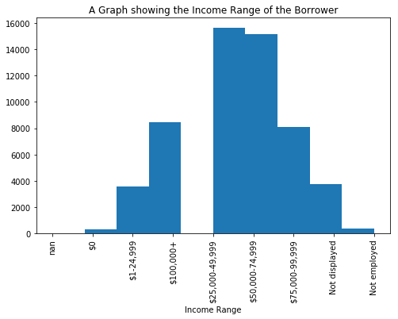

```python
#Let's do some visualization
plt.figure(figsize=[8, 5])
plt.hist(data=new_df, x='IncomeRange')
plt.xlabel('Income Range')
plt.title('A Graph showing the Income Range of the Borrower')
plt.xticks(rotation=(90))
plt.show()
```

```python
new_df['EmploymentStatusDuration'].fillna(0, inplace=True)
```

```python
#Checking if the column contains null values
new_df['EmploymentStatusDuration'].isnull().sum()
```

```
0
```

```python
#Changing the datatype of a column from float into int
new_df['EmploymentStatusDuration'] = new_df['EmploymentStatusDuration'].astype(int)
```

```python
new_df.info()
```

```
<class 'pandas.core.frame.DataFrame'>
RangeIndex: 55267 entries, 0 to 55266
Data columns (total 21 columns):
ListingCreationDate          55267 non-null datetime64[ns]
Occupation                   53557 non-null category
ProsperScore                 41155 non-null float64
BorrowerState                52629 non-null category
IncomeRange                  55266 non-null object
AvailableBankcardCredit      51616 non-null float64
ClosedDate                   26756 non-null datetime64[ns]
LoanOriginalAmount           55266 non-null float64
EmploymentStatus             54198 non-null category
ListingCategory (numeric)    55266 non-null category
LenderYield                  55266 non-null float64
EmploymentStatusDuration     55267 non-null int64
BorrowerRate                 55266 non-null float64
LoanStatus                   55267 non-null category
LP_InterestandFees           55266 non-null float64
StatedMonthlyIncome          55266 non-null float64
MonthlyLoanPayment           55266 non-null float64
DebtToIncomeRatio            51181 non-null float64
LP_ServiceFees               55266 non-null float64
Term                         55267 non-null int64
BorrowerAPR                  55259 non-null float64
dtypes: category(5), datetime64[ns](2), float64(11), int64(2), object(1)
memory usage: 7.0+ MB
```

```python
#new_df.plot(x='IncomeRange', kind='bar');
new_df['LoanOriginalAmount'] = new_df['LoanOriginalAmount'].dropna()
```

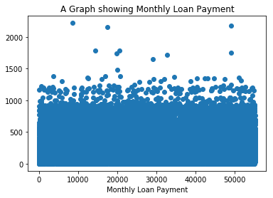

```python
plt.scatter(new_df.index, new_df['MonthlyLoanPayment'])
plt.xlabel('Monthly Loan Payment')
plt.title('A Graph showing Monthly Loan Payment')
#plt.xticks(rotation=45)
plt.show()
```

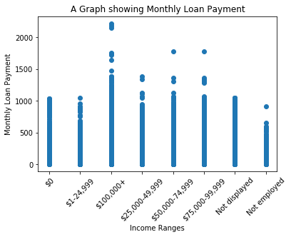

```python
plt.scatter(new_df['IncomeRange'], new_df['MonthlyLoanPayment'])
plt.xlabel('Income Ranges')
plt.ylabel('Monthly Loan Payment')
plt.title('A Graph showing Monthly Loan Payment')
plt.xticks(rotation=45)
plt.show()
```

```python
new_df['Term'].unique()
```

```
array([36, 60, 12])
```

## General Question that can be asked in the datasets

#### 1. Does the Monthly Loan Payment affect the Loan Status

#### 2. Does the Increase in term have effect on the Borrower APR

#### 3. Does the Income Ranges have effect on the Stated Monthly Income

#### 4. Does the Income Ranges on the Monthly Loan Payment?

#### 5. Does the Income Ranges have effect on the LP InterestandFees

#### 6. Does the Employment Status have effect on the a Loan Status

#### 7. Does the LP Interest and Fees have effect on the Loan Status

#### 8. Does the Employment Status affect the BorrowerAPR

#### 9. Does the Borrower APR (Interest Rate) have loan status

### Question-Visualization-Observations

## Question

Q1. Does the increase in term have effect on the BorrowerAPR

## Visualization

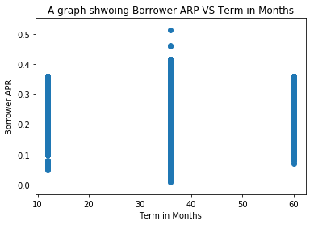

```python
#Wants to examine if the increase in term will have effect on the BorrowerAPR
x= new_df['Term']
y= new_df['BorrowerAPR']
plt.scatter( x, y)
plt.xlabel('Term in Months')
plt.title('A graph shwoing Borrower ARP VS Term in Months')
plt.ylabel('Borrower APR')
plt.show()
```

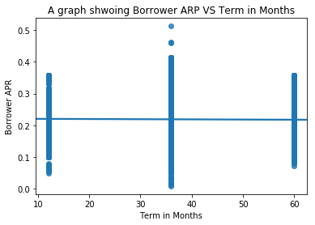

```python
#Wants to examine if the increase in term will have effect on the BorrowerAPR with another plot type
sb.regplot(data=new_df, x='Term', y='BorrowerAPR')
plt.xlabel('Term in Months')
plt.title('A graph shwoing Borrower ARP VS Term in Months')
plt.ylabel('Borrower APR')
plt.show()
```

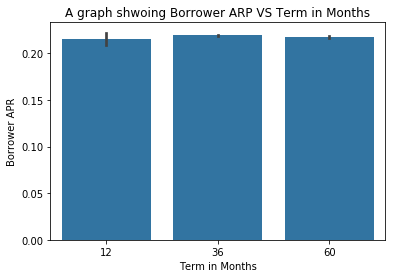

```python
#Wants to examine if the increase in term will have effect on the BorrowerAPR with another plot type
base_color = sb.color_palette()[0]
sb.barplot(data=new_df, x='Term', y='BorrowerAPR', color=base_color)
plt.xlabel('Term in Months')
plt.title('A graph shwoing Borrower ARP VS Term in Months')
plt.ylabel('Borrower APR')
plt.show()
```

## Conclusion Drawn

From the visualization above, I can see that there are some outliers especially in the second term thus `36` and Also from the visualization it can be concluded that the Term does not have effect on the Borrower APR

```python
new_df.describe()
```

|  | ProsperScore | AvailableBankcardCredit | LoanOriginalAmount | LenderYield | EmploymentStatusDuration | BorrowerRate | LP_InterestandFees | StatedMonthlyIncome | MonthlyLoanPayment | DebtToIncomeRatio | LP_ServiceFees | Term | BorrowerAPR |
| --- | --- | --- | --- | --- | --- | --- | --- | --- | --- | --- | --- | --- | --- |
| count | 41155.000000 | 51616.000000 | 55266.000000 | 55266.000000 | 55267.000000 | 55266.000000 | 55266.000000 | 5.526600e+04 | 55266.000000 | 51181.000000 | 55266.000000 | 55267.000000 | 55259.000000 |
| mean | 5.962848 | 11247.779991 | 8338.609851 | 0.182495 | 89.523260 | 0.192556 | 1080.028187 | 5.619012e+03 | 272.271907 | 0.276288 | -54.891990 | 40.851937 | 0.218563 |
| std | 2.376339 | 19863.036686 | 6248.733566 | 0.074581 | 94.313729 | 0.074882 | 1191.047069 | 9.333132e+03 | 191.903943 | 0.550618 | 61.084587 | 10.426270 | 0.080427 |
| min | 1.000000 | 0.000000 | 1000.000000 | -0.010000 | 0.000000 | 0.000000 | -2.349900 | 0.000000e+00 | 0.000000 | 0.000000 | -664.870000 | 12.000000 | 0.008640 |
| 25% | 4.000000 | 885.000000 | 4000.000000 | 0.123500 | 19.000000 | 0.133400 | 271.462500 | 3.208333e+03 | 131.427500 | 0.140000 | -73.085000 | 36.000000 | 0.156290 |
| 50% | 6.000000 | 4123.000000 | 6500.000000 | 0.173000 | 60.000000 | 0.183550 | 700.150000 | 4.666667e+03 | 217.740000 | 0.220000 | -34.355000 | 36.000000 | 0.209310 |
| 75% | 8.000000 | 13183.250000 | 12000.000000 | 0.240000 | 130.000000 | 0.250000 | 1459.400000 | 6.782417e+03 | 372.150000 | 0.320000 | -13.780000 | 36.000000 | 0.283700 |
| max | 11.000000 | 646285.000000 | 35000.000000 | 0.492500 | 755.000000 | 0.497500 | 14329.490000 | 1.750003e+06 | 2218.530000 | 10.010000 | 32.060000 | 60.000000 | 0.512290 |

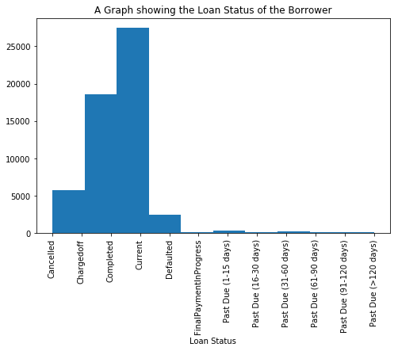

```python
#Let's do some visualization
plt.figure(figsize=[8, 5])
plt.hist(data=new_df, x='LoanStatus')
plt.xlabel('Loan Status')
plt.title('A Graph showing the Loan Status of the Borrower')
plt.xticks(rotation=(90))
plt.show()
```

```python
# # plotting carat on a standard scale
# binsize = 100
# bins = np.arange(0, new_df['LoanOriginalAmount'].max()+binsize, binsize)


# #plt.hist(data = new_df, x = 'LoanOriginalAmount', bins = bins)
# plt.hist(new_df['LoanOriginalAmount'])
# plt.xlim([0,3.5])
# plt.title('A Graph showing the Employment Status Duration')
# plt.xlabel('EmploymentStatusDuration')
# plt.show()


#plt.show()
```

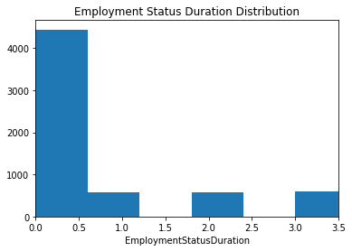

```python
# plotting carat on a standard scale
binsize = 0.6
bins = np.arange(0, new_df['EmploymentStatusDuration'].max()+binsize, binsize)


plt.hist(data = new_df, x = 'EmploymentStatusDuration', bins = bins)
plt.xlim([0,3.5])
plt.title('Employment Status Duration Distribution')
plt.xlabel('EmploymentStatusDuration')
plt.show()
```

### Question-Visualization-Observations

## Question

Q1. Does the Employment Status have effect on the loan Status

```python
new_df['EmploymentStatus'].unique()
```

```
[Self-employed, Employed, Not available, Full-time, Other, NaN, Not employed, Part-time, Retired]
Categories (8, object): [Self-employed, Employed, Not available, Full-time, Other, Not employed, Part-time, Retired]
```

## Visualization

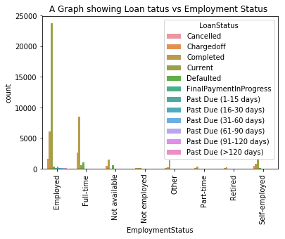

```python
#Getting a countplot since the two variables are qualitative variables
sb.countplot(data=new_df, x='EmploymentStatus', hue='LoanStatus');
plt.title('A Graph showing Loan tatus vs Employment Status ')
plt.xticks(rotation=90);
```

## Conclusion Drawn

From the visualization above, I can see that the Employment Status with value `Full-Time`had the potency to complete the Loan Payment or Cancell the Loan Unlike the Employment Status of `Not employed`

## Univariate Exploration

> In this section, investigate distributions of individual variables. If you see unusual points or outliers, take a deeper look to clean things up and prepare yourself to look at relationships between variables.

> **Rubric Tip**: The project (Parts I alone) should have at least 15 visualizations distributed over univariate, bivariate, and multivariate plots to explore many relationships in the data set. Use reasoning to justify the flow of the exploration.

> **Rubric Tip**: Use the "Question-Visualization-Observations" framework throughout the exploration. This framework involves **asking a question from the data, creating a visualization to find answers, and then recording observations after each visualisation.**

### For the Univariate Exploration, Let me start with some features like the Borrower APR, Loan Original Amount

```python
#I don't understand why it's not working.
# Distribution of Borrower APR in percentage
# binsize = 2
# borrowe_APR_percentage = new_df['BorrowerAPR']*100
# bins = np.arange(new_df['BorrowerAPR'].min()*100, new_df['BorrowerAPR'].max()*100+binsize, binsize)

# plt.figure(figsize=[10, 5])
# plt.hist(x = borrowe_APR_percentage, bins = bins)
# plt.title('Borrower APR Distribution (%)')
# plt.xlabel('Borrower Annual Percentage Rate (%)')
# plt.ylabel('Count')
# plt.xticks([5, 10, 15, 20, 25, 30, 35, 40], ['5','10', '15', '20', '25', '30', '35', '40'])
# plt.show()
```

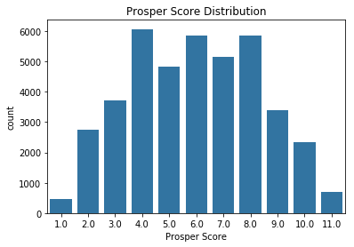

```python
#Prosper Score Distribution (range form 1 to 10)
base_color = sb.color_palette()[0]
sb.countplot(data=new_df, x= 'ProsperScore', color=base_color)
plt.title('Prosper Score Distribution')
plt.xlabel('Prosper Score');
```

```python
#I don't why it's not working.

# Loan Original Amount Distribution
# binsize = 1000
# bins = np.arange(new_df['LoanOriginalAmount'].min(), new_df['LoanOriginalAmount'].max()+binsize, binsize)

# plt.figure(figsize=[10, 8])
# plt.hist(data = new_df, x = 'LoanOriginalAmount', bins = bins)
# plt.title('Loan Original Amount Distribution')
# plt.xlabel('Loan Original Amount in $')
# plt.show()
```

```python
#I don't why it's not working please help me

# Putting Loan Original Amount in a log-scale
# log_binsize = 0.025
# bins = 10 ** np.arange(3, np.log10(new_df['LoanOriginalAmount'].max())+log_binsize, log_binsize)

# plt.figure(figsize=[8, 5])
# plt.hist(data = new_df, x = 'LoanOriginalAmount', bins = bins)
# plt.title('Loan Original Amount distribution with Log scale')
# plt.xscale('log')
# plt.xticks([500, 1e3, 2e3,3e3, 5e3, 1e4, 2e4, 3e4, 5e4], ['500', '1k', '2k', '3k', '5k', '10k', '20k', '30k', '50K'])
# plt.xlabel('Loan Original Amount ($)')
# plt.ylabel('count')
# plt.show()
```

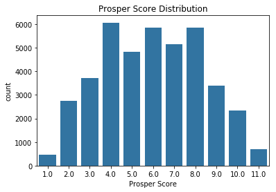

```python
#Prosper Score Distribution (range form 1 to 10)
base_color = sb.color_palette()[0]
sb.countplot(data=new_df, x= 'ProsperScore', color=base_color)
plt.title('Prosper Score Distribution')
plt.xlabel('Prosper Score');
```

#### Prosper Scores are almost normally distributed and values 4, 6, and 8 are the most common.

```python
#Checking loans' term (expressed in months)
new_df['Term'].value_counts()
```

```
36    42578
60    11931
12      758
Name: Term, dtype: int64
```

- So we can see that in years terms can be either 1 year (12 month) or 3 years (36 months) or 5 years (60 months)

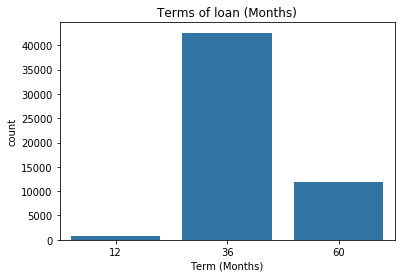

```python
base_color = sb.color_palette()[0]
sb.countplot(data=new_df,x= 'Term',color=base_color);
plt.title('Terms of loan (Months)')
plt.xlabel('Term (Months)');
```

- We see that most of the values are in the 3 years (36 months)

```python
#I don't why it's not working.

#Lender Yield Distribution
# binsize = 0.01
# bins = np.arange(new_df['LenderYield'].min(), new_df['LenderYield'].max()+binsize, binsize)

# plt.figure(figsize=[8, 5])
# plt.hist(data = new_df, x = 'LenderYield', bins = bins)
# plt.xlabel('Lender Yield')
# plt.title('Lender Yield Distribution')
# plt.ylabel('count')
# plt.show()
```

```python
#I don't why it's not working please explain how to solve it

# Service Fees Distribution
# binsize = 50
# bins = np.arange(new_df['LP_ServiceFees'].min(), new_df['LP_ServiceFees'].max()+binsize, binsize)

# plt.figure(figsize=[10, 5])
# plt.hist(data = new_df, x = 'LP_ServiceFees', bins = bins)
# plt.xlabel('Service Fees $')
# plt.title('Service Fees Distribution')
# plt.ylabel('count')
# plt.show()
```

```python
#I don't why it's not working.

# Monthly loan payment distribution
# binsize = 50
# bins = np.arange(0, new_df['MonthlyLoanPayment'].max()+binsize, binsize)

# plt.figure(figsize=[8, 5])
# plt.hist(data = new_df, x = 'MonthlyLoanPayment', bins = bins)
# plt.xlabel('Loan Monthly Payment ($)')
# plt.ylabel('count')
# plt.title('Monthly loan payment distribution')
# plt.show()
```

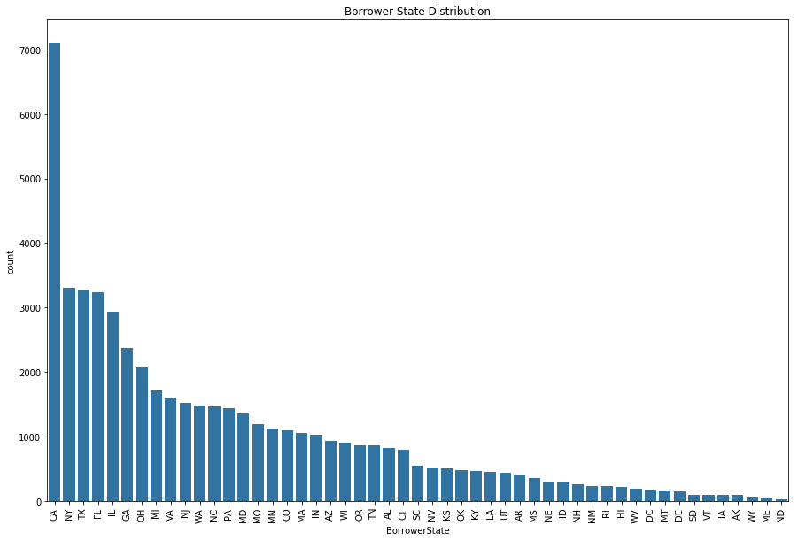

```python
#Borrower State Distrobution
cat_order = new_df['BorrowerState'].value_counts().index
plt.figure(figsize=[15, 10])
sb.countplot(data=new_df,x='BorrowerState',color=base_color, order=cat_order);
plt.title('Borrower State Distribution');
plt.xticks(rotation=90);
```

- We can see that California (CA), Texas (TX) and New York (NY) have the 3 biggest numbers of loans originated in that period of time.

```
Text(0.5,1,'Borrower Income Range Distribution')
```

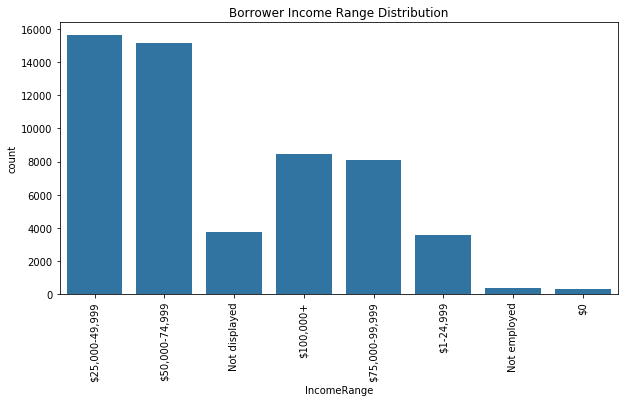

```python
#Borrower Income Range Status Distrobution
plt.figure(figsize=[10, 5])
sb.countplot(data=new_df,x='IncomeRange',color=base_color);
plt.xticks(rotation=90)
plt.title('Borrower Income Range Distribution')
```

- We can see that People with income range of $25000-49999 are the ones who are taking loans most

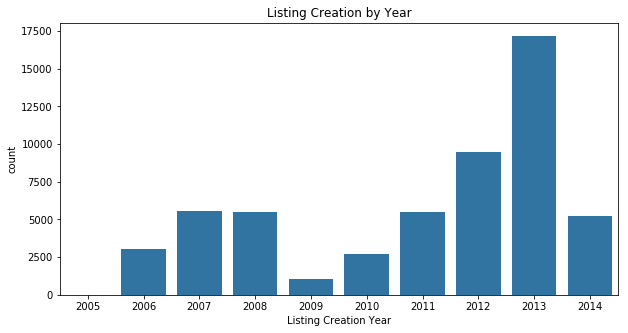

```python
# Listing Creation  by Year
plt.figure(figsize=[10, 5])
sb.countplot(data=new_df,x=new_df['ListingCreationDate'].dt.year,color=base_color)
plt.title('Listing Creation by Year')
plt.xlabel('Listing Creation Year');
```

- The same observation as the previous chart which is expected because we normally create the list every year.

### Discuss the distribution(s) of your variable(s) of interest. Were there any unusual points? Did you need to perform any transformations?

> Year 2013 had the highest loan creation. California (CA) had the biggest number of loans. We can see that People with income range of `$25000-49999` are the ones who are taking loans most.

### Of the features you investigated, were there any unusual distributions? Did you perform any operations on the data to tidy, adjust, or change the form of the data? If so, why did you do this?

> Also I had a problem with the Loan Original Amount, Monthly Loan Payment, Service Fees, LenderYield Distribution, and Borrower APR Distributions

## Bivariate Exploration

> In this section, investigate relationships between pairs of variables in your data. Make sure the variables that you cover here have been introduced in some fashion in the previous section (univariate exploration).

```python
new_df.info()
```

```
<class 'pandas.core.frame.DataFrame'>
RangeIndex: 55267 entries, 0 to 55266
Data columns (total 21 columns):
ListingCreationDate          55267 non-null datetime64[ns]
Occupation                   53557 non-null category
ProsperScore                 41155 non-null float64
BorrowerState                52629 non-null category
IncomeRange                  55266 non-null object
AvailableBankcardCredit      51616 non-null float64
ClosedDate                   26756 non-null datetime64[ns]
LoanOriginalAmount           55266 non-null float64
EmploymentStatus             54198 non-null category
ListingCategory (numeric)    55266 non-null category
LenderYield                  55266 non-null float64
EmploymentStatusDuration     55267 non-null int64
BorrowerRate                 55266 non-null float64
LoanStatus                   55267 non-null category
LP_InterestandFees           55266 non-null float64
StatedMonthlyIncome          55266 non-null float64
MonthlyLoanPayment           55266 non-null float64
DebtToIncomeRatio            51181 non-null float64
LP_ServiceFees               55266 non-null float64
Term                         55267 non-null int64
BorrowerAPR                  55259 non-null float64
dtypes: category(5), datetime64[ns](2), float64(11), int64(2), object(1)
memory usage: 7.0+ MB
```

```python
categorical_variables = ['Occupation', 'BorrowerState', 'EmploymentStatus', 'ListingCategory (numeric)', 'LoanStatus']
numeric_variables = ['Term', 'ProsperScore', 'LoanOriginalAmount', 'LenderYield', 'BorrowerRate', 'StatedMonthlyIncome', 'MonthlyLoanPayment','LP_ServiceFees', 'LP_InterestandFees', 'BorrowerAPR']
```

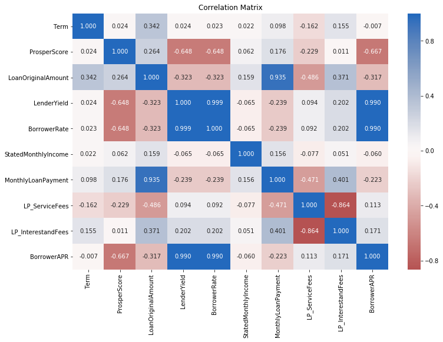

```python
# Correlation matrix for all numeric variables
plt.figure(figsize = [12, 8])
sb.heatmap(new_df[numeric_variables].corr(), annot = True, fmt = '.3f',
           cmap = 'vlag_r', center = 0)
plt.title('Correlation Matrix')
plt.show()
```

```python
# plot matrix: sample 500 loans so that plots are clearer and
# they render faster
# samples = np.random.choice(new_df.shape[0], 500, replace = False)
# new_df_samp = new_df.loc[samples,:]

# g = sb.PairGrid(data = new_df_samp, vars = numeric_variables)
# g = g.map_diag(plt.hist, bins = 20);
# g.map_offdiag(plt.scatter);
```

[output not shown]

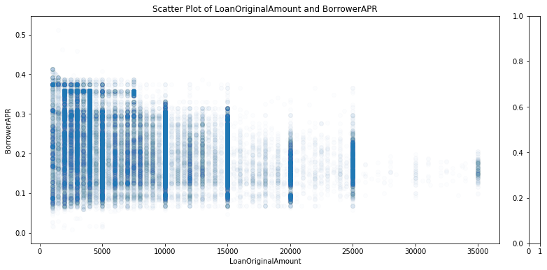

```python
# Checking the relation between LoanOriginalAmount and BorrowerAPR

plt.figure(figsize = [15, 6])
#plt.subplot(1, 2, 1)
plt.scatter(data = new_df, x = 'LoanOriginalAmount', y = 'BorrowerAPR',  alpha =  0.01)
plt.title('Scatter Plot of LoanOriginalAmount and BorrowerAPR')
plt.xlabel('LoanOriginalAmount')
plt.ylabel('BorrowerAPR');
plt.colorbar();
```

```python
#plt.subplot(1, 2, 2)
bins_x = np.arange(new_df['LoanOriginalAmount'].min(), new_df['LoanOriginalAmount'].max()+1000, 1000)
bins_y = np.arange(new_df['BorrowerAPR'].min(), new_df['BorrowerAPR'].max()+0.1, 0.1)
plt.hist2d(data = new_df, x = 'LoanOriginalAmount', y = 'BorrowerAPR', bins = [bins_x, bins_y],
               cmap = 'viridis_r', cmin = 0.5)
plt.title('HeatMap of LoanOriginalAmount and BorrowerAPR')
plt.xlabel('LoanOriginalAmount')
plt.ylabel('BorrowerAPR');
```

[output not shown]

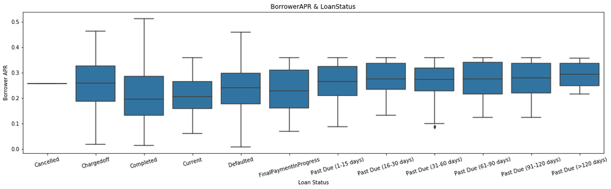

```python
# Borrower APR vs Status of Loan
plt.figure(figsize = [20, 5])
sb.boxplot(data=new_df,y='BorrowerAPR',x='LoanStatus',color=base_color);
plt.title('BorrowerAPR & LoanStatus');
plt.ylabel('Borrower APR');
plt.xlabel('Loan Status');
plt.xticks(rotation=15);
```

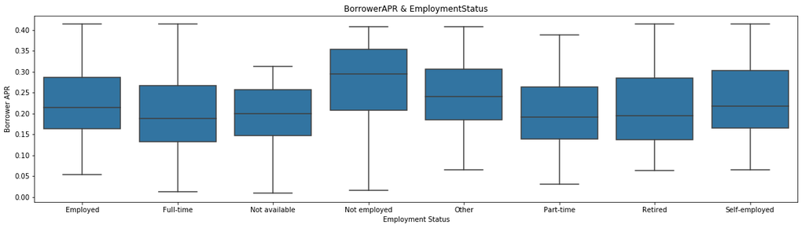

```python
# Borrower APR vs Employment status
plt.figure(figsize = [20, 5])

sb.boxplot(data=new_df,y='BorrowerAPR',x='EmploymentStatus',color=base_color);
plt.title('BorrowerAPR & EmploymentStatus');
plt.ylabel('Borrower APR');
plt.xlabel('Employment Status');
```

- On BorrowerAPR vs LoanStatus graph we notice that Current and completed loans have lower rate than the past-due loans and have lower mean.
- On BorrowerAPR vs Employment status graph we notice that Employed people have lower IQR than not employed.

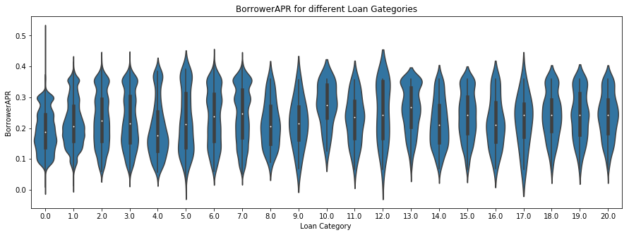

```python
plt.figure(figsize = [15, 5])
sb.violinplot(data=new_df,x='ListingCategory (numeric)', y='BorrowerAPR',color=base_color);
plt.title('BorrowerAPR for different Loan Gategories')
plt.xlabel('Loan Category ');
plt.ylabel('BorrowerAPR');
```

- We can see that Cosmetic Procedure are given higer interest rates with data distributed well in it.
- Listing Category: The category of the listing that the borrower selected when posting their listing: 0 - Not Available, 1 - Debt Consolidation, 2 - Home Improvement, 3 - Business, 4 - Personal Loan, 5 - Student Use, 6 - Auto, 7- Other, 8 - Baby&Adoption, 9 - Boat, 10 - Cosmetic Procedure, 11 - Engagement Ring, 12 - Green Loans, 13 - Household Expenses, 14 - Large Purchases, 15 - Medical/Dental, 16 - Motorcycle, 17 - RV, 18 - Taxes, 19 - Vacation, 20 - Wedding Loans

### Did you observe any interesting relationships between the other features (not the main feature(s) of interest)?

> The loan status for the past dues have a high interest rate. Number of Defaulted loans for Self-employed people are larger than those for Not Employed

## Multivariate Exploration

> Create plots of three or more variables to investigate your data even further. Make sure that your investigations are justified, and follow from your work in the previous sections.

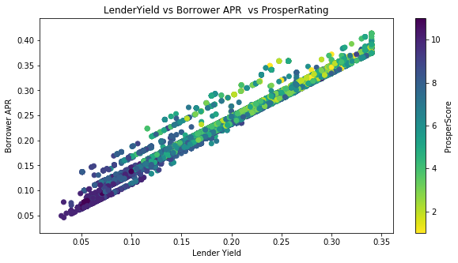

```python
# LenderYield vs Borrower APR  vs ProsperRating
plt.figure(figsize = [10, 5])
plt.scatter(data=new_df,x='LenderYield',y = 'BorrowerAPR',c='ProsperScore',cmap = 'viridis_r')
plt.colorbar(label = 'ProsperScore');
plt.title('LenderYield vs Borrower APR  vs ProsperRating');
plt.xlabel('Lender Yield');
plt.ylabel('Borrower APR');
```

We can see that the relationship between all variables are clear. Borrower APR and Lender yield are directly positively correlated as when the interest borrowers pays more , the lender yield will increase. Higher the prosper score lower will lower borrower apr and then the lender yield will also be lower.

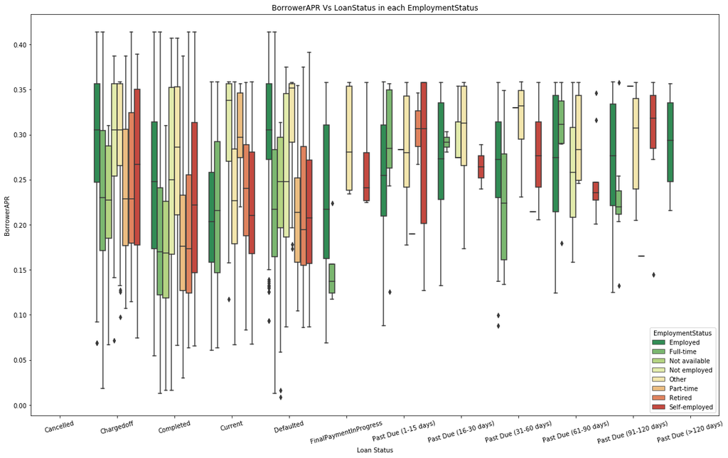

```python
# LoanStatus Vs BorrowerAPR in each EmploymentStatus
plt.figure(figsize=[20,12])
sb.boxplot(x="LoanStatus", y="BorrowerAPR", hue="EmploymentStatus", data=new_df, palette="RdYlGn_r");
plt.title('BorrowerAPR Vs LoanStatus in each EmploymentStatus');
plt.xlabel('Loan Status');
plt.ylabel('BorrowerAPR');
plt.xticks(rotation = 15);
```

```python
new_df['LoanStatus'].value_counts()
```

```
Current                   27426
Completed                 18539
Chargedoff                 5799
Defaulted                  2418
Past Due (1-15 days)        381
Past Due (31-60 days)       191
Past Due (91-120 days)      152
Past Due (61-90 days)       143
Past Due (16-30 days)       111
FinalPaymentInProgress       97
Past Due (>120 days)          9
Cancelled                     1
Name: LoanStatus, dtype: int64
```

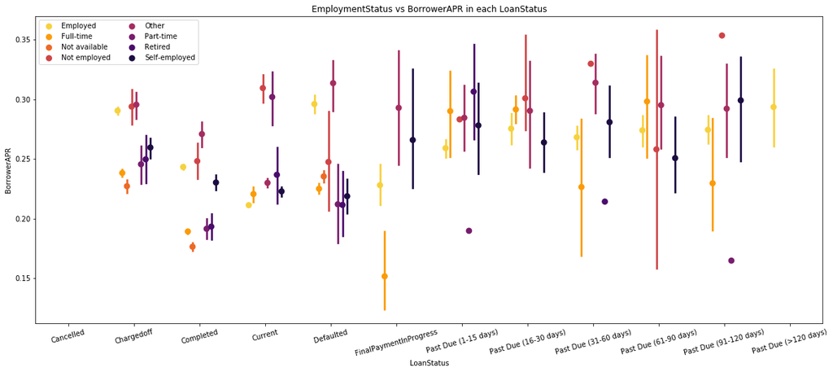

```python
# EmploymentStatus vs BorrowerAPR in each LoanStatus
fig = plt.figure(figsize = [20,8])
ax = sb.pointplot(data = new_df, x = 'LoanStatus', y = 'BorrowerAPR', hue = 'EmploymentStatus', linestyles = "",
                  dodge = 0.5, palette = 'inferno_r')
plt.title('EmploymentStatus vs BorrowerAPR in each LoanStatus')
plt.ylabel('BorrowerAPR')
plt.xticks(rotation=15)
plt.legend(ncol=2)
plt.show();
```

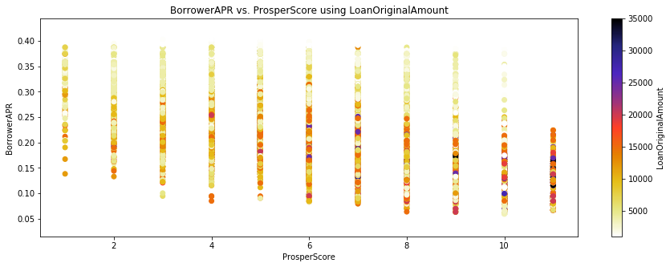

```python
# BorrowerAPR vs. CreditScoreRangeUpper & CreditScoreRangeUpper
plt.figure(figsize = [15, 5])
cm = plt.cm.get_cmap('CMRmap_r')
plt.scatter(data=new_df[new_df['StatedMonthlyIncome']<20000],x='ProsperScore',y='BorrowerAPR',c='LoanOriginalAmount',cmap=cm)
plt.colorbar(label = 'LoanOriginalAmount')
plt.title('BorrowerAPR vs. ProsperScore using LoanOriginalAmount')
plt.xlabel('ProsperScore')
plt.ylabel('BorrowerAPR');
```

- We can see that most of the loans with higher amounts (>$20,000) are taken by people with higher prosper score (10 and above)

### Were there any interesting or surprising interactions between features?

> Scatter plot and Heatmap were also created to find out that ProsperScore and BorrowerAPR were negatively correlated as higher the prosper score lower will be the risk attached hence lower will be the APR and that further lowers down the yield.

## Conclusions

> I am very glad to do this visualization with the Prosper Loan Dataset even though I faced certain difficulties I couldn't rectify.

> Remove all Tips mentioned above, before you convert this notebook to PDF/HTML

> At the end of your report, make sure that you export the notebook as an html file from the `File > Download as... > HTML or PDF` menu. Make sure you keep track of where the exported file goes, so you can put it in the same folder as this notebook for project submission. Also, make sure you remove all of the quote-formatted guide notes like this one before you finish your report!